# Analysis_Tulip_Final

Trang Tu

2023-05-27

# Prepare data:

## Poisson data

```r
data_count <- read.csv("count_data_G8.csv")

data_count$subplotID = as.factor(data_count$subplotID)
data_count$species = as.factor(data_count$species)
data_count$garden = as.factor(data_count$garden)
data_count$rater = as.factor(data_count$rater)
data_count <- data_count %>% mutate(compound = paste("C", data_count$compound, sep=""))
data_count$compound = factor(data_count$compound,
                             levels=c("C1", "C2", "C3","C4","C5","C6","C7","C8","C9","C10","C11","C12","C13","C14","C15"),
                             labels= c("Water", "Apathic Acid",  "Beerse Brew",
                                       "Concentrate of Caducues", "Distillate of Discovery",
                                       "Essence of Epiphaneia", "Four in December",
                                       "Granules of Geheref", "Kar-Hamel Mooh",
                                       "Lucifer's Liquid", "Noospherol",
                                       "Oil of John's son", "Powder of Perlimpinpin",
                                       "Spirit of Scienza", "Zest of Zen"))
```

The data set is missing 49 observations (3.3%) of the outcome rose longevity. We will employ complete case analysis, as the missing data is insignificant and has been taken into account in sample size calculation.

```r
data_no_miss = data_count %>% drop_na(tot.vase.days)
```

## Binary data

Transform the poisson outcome ‘tot.vase.days’ into a longitudinal binary outcome (i.e. fresh=1/not fresh=0):

```r
binary_data <- as.data.frame(matrix(NA, nrow = nrow(data_no_miss)*25, ncol=ncol(data_no_miss)))
names(binary_data) <- names(data_no_miss)
for(i in 1: ncol(data_no_miss))
{
  binary_data[,i] <- rep(data_no_miss[,i], each = 25)
}
binary_data <- binary_data %>% mutate(day= rep(1:25, times= nrow(data_no_miss)), freshness = if_else(day <= tot.vase.days, 1, 0))
binary_data$flowerID <- as.factor(binary_data$flowerID)
```

```r
binary_data2 <- as.data.frame(matrix(NA, nrow = nrow(data_no_miss)*25, ncol=ncol(data_no_miss)))
names(binary_data2) <- names(data_no_miss)
for(i in 1: ncol(data_no_miss))
{
  binary_data2[,i] <- rep(data_no_miss[,i], each = 25)
}
binary_data2 <- binary_data2 %>% mutate(day= rep(0:24, times= nrow(data_no_miss)), freshness = if_else(day <= tot.vase.days-1, 1, 0))
binary_data2$flowerID <- as.factor(binary_data2$flowerID)
```

## Continuous data “Width of the flower”:

```r
conti_data <- read.csv("gaussian_data_G8.csv")
```

```r
conti_data_long <- conti_data %>%
  pivot_longer(-c(Flower_index:Subplot),
               names_to = 'T',
               values_to = "width") %>%
  mutate(day = parse_number(T),
         Type = as_factor(Type),
         Subplot = as_factor(Subplot),
         Garden = as_factor(Garden),
         Rater = as_factor(Rater),
         Compound =
           factor(Compound,
                  levels = c(1:15),
                  labels = c("Water", "Apathic Acid",  "Beerse Brew",
                             "Concentrate of Caducues", "Distillate of Discovery",
                             "Essence of Epiphaneia", "Four in December",
                             "Granules of Geheref", "Kar-Hamel Mooh",
                             "Lucifer's Liquid", "Noospherol",
                             "Oil of John's son", "Powder of Perlimpinpin",
                             "Spirit of Scienza", "Zest of Zen")))

conti_data_long <- na.omit(conti_data_long)
```

There is 3% missing data for the outcome variable “flower width”, which is negligible. Thus we will perform complete case analysis.

# 1. Data exploration

## Count data

Distribution of count outcome (rose longegivity) per compound:

```r
table1(~ tot.vase.days |compound, data = data_no_miss)
```

|  | Water (N=98) | Apathic Acid (N=98) | Beerse Brew (N=98) | Concentrate of Caducues (N=96) | Distillate of Discovery (N=97) | Essence of Epiphaneia (N=97) | Four in December (N=95) | Granules of Geheref (N=98) | Kar-Hamel Mooh (N=96) | Lucifer's Liquid (N=93) | Noospherol (N=97) | Oil of John's son (N=96) | Powder of Perlimpinpin (N=98) | Spirit of Scienza (N=96) | Zest of Zen (N=98) | Overall (N=1451) |
| --- | --- | --- | --- | --- | --- | --- | --- | --- | --- | --- | --- | --- | --- | --- | --- | --- |
| tot.vase.days |  |  |  |  |  |  |  |  |  |  |  |  |  |  |  |  |
| Mean (SD) | 13.5 (4.64) | 17.3 (4.67) | 15.8 (4.62) | 11.6 (4.30) | 14.0 (4.19) | 17.3 (4.39) | 13.5 (4.54) | 12.5 (4.45) | 13.6 (4.39) | 12.0 (4.48) | 14.8 (4.90) | 13.1 (4.72) | 14.9 (4.91) | 15.2 (4.49) | 14.5 (4.50) | 14.3 (4.82) |
| Median [Min, Max] | 13.0 [3.00, 25.0] | 17.0 [5.00, 25.0] | 16.0 [5.00, 25.0] | 11.0 [3.00, 24.0] | 14.0 [4.00, 25.0] | 17.0 [7.00, 25.0] | 13.0 [3.00, 25.0] | 12.5 [4.00, 25.0] | 14.0 [4.00, 24.0] | 12.0 [4.00, 24.0] | 14.0 [5.00, 25.0] | 13.0 [2.00, 25.0] | 15.0 [4.00, 25.0] | 15.0 [6.00, 25.0] | 15.0 [3.00, 24.0] | 14.0 [2.00, 25.0] |

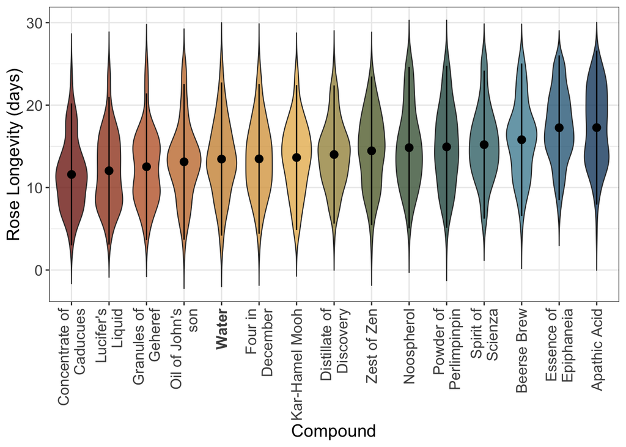

```r
data_no_miss <- data_no_miss %>%
  mutate(compound2 = str_wrap(compound, width = 15) %>% reorder(tot.vase.days))

colors_ = met.brewer("Tiepolo", 15)[1:15]

violin_plot <- data_no_miss %>%
  ggplot(aes(x = compound2, y = tot.vase.days, fill = compound2)) +
  geom_violin(trim = FALSE, linewidth = 0.4, alpha = 0.8) +
  stat_summary(fun.data = "mean_sdl",
               geom = "pointrange",
               color = "black") +
  scale_fill_manual(values = colors_) +
  theme_bw() +
  labs(y = "Rose Longevity (days)", x = "Compound") +
  theme(axis.text=element_text(size = 12),
        axis.title = element_text(size = 14),
        legend.position = "none",
        axis.text.x = element_text(angle = 90, hjust = 1, vjust = 0.5, face = c(rep("plain", 4), "bold",rep("plain", 10))))
violin_plot
```

```r
ggsave("violin_plot2.png",
       violin_plot,
       device = ragg::agg_png, res = 400, units = "in", h = 6, w = 8)
```

The violin plot visualize the marginal distribution of rose longevity per compound. Several compounds, notably compound #2 and #6, provided higher mean rose longevity than distilled water (compound #1), while some compounds (e.g. #4 and #10), performed worse than distilled water.

## Binary data

proportion of fresh flower over time by compound

```r
flower_per_compound <- data_no_miss %>%
  group_by(compound) %>%
  count(compound) %>%
  ungroup()

fresh_over_time <- binary_data %>%
  group_by(compound, day) %>%
  summarise(n_fresh = sum(freshness)) %>%
  ungroup() %>%
  left_join(flower_per_compound, by = 'compound') %>%
  mutate(prop_fresh = n_fresh/n)
fresh_over_time_water_c2_c6 <- fresh_over_time %>%
  filter(compound %in% c("Water", "Apathic Acid", "Essence of Epiphaneia"))

fresh_over_time_excluding_water_c2_c6 <- fresh_over_time %>%
  filter(!compound %in% c("Water", "Apathic Acid", "Essence of Epiphaneia"))
```

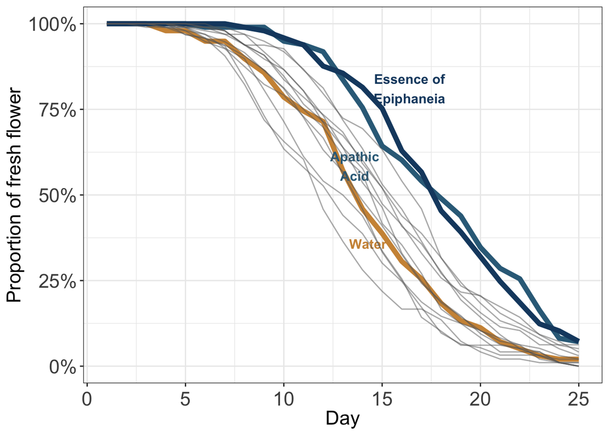

```r
fresh_over_time_water_c2_c6 <- fresh_over_time_water_c2_c6 %>%
  mutate(label = ifelse(day == 15, str_wrap(as.character(compound), width = 10), NA))


plot_fresh_flower_highlight <- ggplot(data = fresh_over_time_water_c2_c6,
                                      aes(x = day, y = prop_fresh, color = compound, group = compound)) +
  geom_line(size = 2) +
  scale_colour_manual(values = c('#CE9344', '#336B88', '#17486F')) +
  # geom_label(aes(label = label), x = 15, size = 5, fontface = 'bold', show_guide = FALSE) +
  geom_text_repel(aes(label = label), x = 15, size = 3.9, fontface = 'bold', show_guide = FALSE) +
  geom_line(data = fresh_over_time_excluding_water_c2_c6,
            aes(x = day, y = prop_fresh, color = compound, group = compound), alpha = 0.5, colour = "grey40") +
  theme_bw() +
  scale_y_continuous(labels = scales::percent_format(accuracy = 1)) +
  # scale_x_continuous(limits = c(0, 22)) +
  labs(x = "Day", y = "Proportion of fresh flower") +
  theme(axis.text.x = element_text(size = 16, vjust = .5),
        axis.text.y = element_text(size = 16),
        plot.title = element_text(size = 16),
        axis.text = element_text(size = 16),
        axis.title.x = element_text(size = 16),
        axis.title.y = element_text(size = 16),
        plot.caption = element_text(hjust = 0, size = 16),
        legend.title = element_blank(),
        legend.text = element_blank()) +
  theme(legend.position = "none")
ggsave("plot_fresh_flower_highlight.png",
       plot_fresh_flower_highlight,
       device = ragg::agg_png, res = 400, units = "in", h = 8, w = 12)
plot_fresh_flower_highlight
```

## Continuous data

Mean width of flower per compound:

```r
conti_data_long1 <- conti_data_long %>% filter(day == 0)
conti_data_long1 %>% group_by(Compound) %>% count(Compound)
```

```
## # A tibble: 15 × 2
## # Groups:   Compound [15]
##    Compound                    n
##    <fct>                   <int>
##  1 Water                      12
##  2 Apathic Acid               12
##  3 Beerse Brew                12
##  4 Concentrate of Caducues    12
##  5 Distillate of Discovery    12
##  6 Essence of Epiphaneia      12
##  7 Four in December           12
##  8 Granules of Geheref        12
##  9 Kar-Hamel Mooh             12
## 10 Lucifer's Liquid           12
## 11 Noospherol                 12
## 12 Oil of John's son          12
## 13 Powder of Perlimpinpin     12
## 14 Spirit of Scienza          12
## 15 Zest of Zen                12
```

```r
mean_width <- conti_data_long %>%
  group_by(day, Compound) %>%
  summarise(width = mean(width))
```

[output not shown]

```r
mean_width
```

```
## # A tibble: 315 × 3
## # Groups:   day [21]
##      day Compound                width
##    <dbl> <fct>                   <dbl>
##  1     0 Water                    4.35
##  2     0 Apathic Acid             3.19
##  3     0 Beerse Brew              3.95
##  4     0 Concentrate of Caducues  4.49
##  5     0 Distillate of Discovery  4.15
##  6     0 Essence of Epiphaneia    2.9
##  7     0 Four in December         3.92
##  8     0 Granules of Geheref      4.32
##  9     0 Kar-Hamel Mooh           4.33
## 10     0 Lucifer's Liquid         4.65
## # ℹ 305 more rows
```

```r
mean_width_c2_c6_water_c10_c4 <- mean_width %>%
  filter(Compound %in% c("Water", "Apathic Acid","Essence of Epiphaneia", "Lucifer's Liquid", "Concentrate of Caducues"))

mean_width_excluding_c2_c6_water_c10_c14 <- mean_width %>%
  filter(!Compound %in% c("Water", "C2", "C6", "C10", "C4"))

mean_width_c2_c6_water_c10_c4 <- mean_width_c2_c6_water_c10_c4 %>%
  mutate(label = ifelse(day == 20, as.character(Compound), NA))

mean_width_c2_c6_water_c10_c4 <- mean_width_c2_c6_water_c10_c4 %>%
  mutate(label2 = str_wrap(label, width = 12))

plot_width_2 <- ggplot(data = mean_width_c2_c6_water_c10_c4,
       aes(x = day, y = width, color = Compound, group = Compound)) +
  geom_line(size = 2) +
  scale_colour_manual(values = c('#17486F', '#336B88', '#CE9344', "#A04526", "#802417")) +
  geom_text_repel(aes(label = label2), x = 21.6, size = 4, fontface = 'bold', show_guide = FALSE) +
  geom_line(data = mean_width_excluding_c2_c6_water_c10_c14,
            aes(x = day, y = width, color = Compound, group = Compound), colour = "grey40") +
  labs(x = "Day", y = "Flower Width (cm)") +
  theme_tq() +
  xlim(0, 22) +
  theme(axis.text.x = element_text(size = 16, vjust = .5),
        axis.text.y = element_text(size = 16),
        plot.title = element_text(size = 16),
        axis.text = element_text(size = 16),
        axis.title.x = element_text(size = 16),
        axis.title.y = element_text(size = 16),
        plot.caption = element_text(hjust = 0, size = 16),
        legend.title = element_blank(),
        legend.text = element_blank()) +
  theme(legend.position = "none")

ggsave("plot_width_2.png",
       plot_width_2,
       device = ragg::agg_png, res = 400, units = "in", h = 8, w = 12)
```

# 2.Effect estimation

## 2.1.Poisson model for count data

### GEE for poisson data

In this model, because we can only specify one cluster, we create a new ID indicating sub-cluster of rater and subplot.

```r
#create new ID incorporating subplot and rater:
data_no_miss_gee <- data_no_miss %>% mutate(plot_rater = paste(rater,"-",subplotID, sep =""))
data_no_miss_gee$plot_rater <- as.factor(data_no_miss_gee$plot_rater)
data_no_miss_gee <- data_no_miss_gee %>% arrange(plot_rater)
```

We choose “exchangeable” as the primary correlation structures within cluster, each pair of observations in a group has the same correlation. To choose the appropriate correlation structure, we use QIC. CIC has been suggested as a more robust alternative to QIC when the model for the mean may not fit the data very well and when models with different correlation structures are compared.

Models with smaller values of QIC, CIC, QICu, or QICC are preferred.

```r
m_poisson_gee <- geeglm(tot.vase.days ~ compound + garden+species,id=plot_rater, family = poisson, data = data_no_miss_gee, corstr = "exchangeable")

sum_gee <- summary(m_poisson_gee)
sum_gee
```

```
##
## Call:
## geeglm(formula = tot.vase.days ~ compound + garden + species,
##     family = poisson, data = data_no_miss_gee, id = plot_rater,
##     corstr = "exchangeable")
##
##  Coefficients:
##                                   Estimate    Std.err     Wald Pr(>|W|)
## (Intercept)                      2.6095652  0.0381484 4679.321  < 2e-16 ***
## compoundApathic Acid             0.2643930  0.0412431   41.096 1.45e-10 ***
## compoundBeerse Brew              0.1495835  0.0423034   12.503 0.000406 ***
## compoundConcentrate of Caducues -0.1388781  0.0458251    9.185 0.002441 **
## compoundDistillate of Discovery  0.0526034  0.0409721    1.648 0.199183
## compoundEssence of Epiphaneia    0.2421356  0.0371477   42.487 7.12e-11 ***
## compoundFour in December         0.0111340  0.0431487    0.067 0.796377
## compoundGranules of Geheref     -0.0669029  0.0450654    2.204 0.137656
## compoundKar-Hamel Mooh           0.0260018  0.0451308    0.332 0.564519
## compoundLucifer's Liquid        -0.0942364  0.0490593    3.690 0.054749 .
## compoundNoospherol               0.1015634  0.0441113    5.301 0.021311 *
## compoundOil of John's son       -0.0223702  0.0464511    0.232 0.630100
## compoundPowder of Perlimpinpin   0.1078362  0.0461681    5.456 0.019505 *
## compoundSpirit of Scienza        0.1256438  0.0437494    8.248 0.004080 **
## compoundZest of Zen              0.0638230  0.0472735    1.823 0.176991
## garden2                         -0.0002303  0.0230112    0.000 0.992013
## species2                        -0.0346996  0.0149611    5.379 0.020378 *
## ---
## Signif. codes:  0 '***' 0.001 '**' 0.01 '*' 0.05 '.' 0.1 ' ' 1
##
## Correlation structure = exchangeable
## Estimated Scale Parameters:
##
##             Estimate Std.err
## (Intercept)    1.455 0.06059
##   Link = identity
##
## Estimated Correlation Parameters:
##       Estimate Std.err
## alpha   0.3232 0.03778
## Number of clusters:   390  Maximum cluster size: 10
```

```r
m_poisson_gee2 <- geeglm(tot.vase.days ~ compound + garden+species,id=plot_rater, family = poisson, data = data_no_miss_gee, corstr = "unstructured")

QIC(m_poisson_gee, m_poisson_gee2)
```

```
##                   QIC   QICu Quasi Lik   CIC params   QICC
## m_poisson_gee  -68808 -68807     34420 16.19     17 -68807
## m_poisson_gee2 -68801 -68801     34418 17.21     17 -68777
```

Output interpretation: The column labeled Wald in the summary table is the square of the z-statistic reported by the gee function. Both the z-statistic and its square are variously referred to as Wald statistics. The square of a standard normal random variable is a chi-squared random variable with 1 degree of freedom, chisq1. So, the reported p-values are the upper tailed probabilities from a chisq1 distribution and test whether the true parameter value is different from zero.

Model with exchangeable correlation structure yielded smaller QIC than unstructured. => Choose “Exchangeable” correlation structure.

Output visualization

```r
options(scipen=999)
effect_gee = round(exp(sum_gee$coefficients[,1]), digits = 3)
conf.low_gee <- round(exp(sum_gee$coefficients[,1] + qnorm(0.025)*sum_gee$coefficients[,2]) , digits = 3)
conf.high_gee <- round(exp(sum_gee$coefficients[,1] + qnorm(0.975)*sum_gee$coefficients[,2]) , digits = 3)
right_p_value_gee <- round(if_else(sum_gee$coefficients[,1] >0, sum_gee$coefficients[,4]/2, 1 -(sum_gee$coefficients[,4]/2)), digits = 5) #right-sided p-value
output_gee<- data.frame( cbind(effect_gee, conf.low_gee, conf.high_gee, right_p_value_gee))
output_gee<- output_gee %>% mutate(term = rownames(sum_gee$coefficients)) %>% relocate(term)
output_gee$term <- as.factor(output_gee$term)
output_gee
```

```
##                               term effect_gee conf.low_gee conf.high_gee
## 1                      (Intercept)     13.593       12.614        14.648
## 2             compoundApathic Acid      1.303        1.201         1.412
## 3              compoundBeerse Brew      1.161        1.069         1.262
## 4  compoundConcentrate of Caducues      0.870        0.796         0.952
## 5  compoundDistillate of Discovery      1.054        0.973         1.142
## 6    compoundEssence of Epiphaneia      1.274        1.185         1.370
## 7         compoundFour in December      1.011        0.929         1.100
## 8      compoundGranules of Geheref      0.935        0.856         1.022
## 9           compoundKar-Hamel Mooh      1.026        0.939         1.121
## 10        compoundLucifer's Liquid      0.910        0.827         1.002
## 11              compoundNoospherol      1.107        1.015         1.207
## 12       compoundOil of John's son      0.978        0.893         1.071
## 13  compoundPowder of Perlimpinpin      1.114        1.017         1.219
## 14       compoundSpirit of Scienza      1.134        1.041         1.235
```

[output cut: 21 more lines]

```r
output_gee2 <- output_gee %>% slice(-c(1,16,17))
output_gee2 <- output_gee2 %>% mutate(adjust_right_p_value_gee = p.adjust(output_gee2$right_p_value_gee, method = "holm"))
output_gee2
```

```
##                               term effect_gee conf.low_gee conf.high_gee
## 1             compoundApathic Acid      1.303        1.201         1.412
## 2              compoundBeerse Brew      1.161        1.069         1.262
## 3  compoundConcentrate of Caducues      0.870        0.796         0.952
## 4  compoundDistillate of Discovery      1.054        0.973         1.142
## 5    compoundEssence of Epiphaneia      1.274        1.185         1.370
## 6         compoundFour in December      1.011        0.929         1.100
## 7      compoundGranules of Geheref      0.935        0.856         1.022
## 8           compoundKar-Hamel Mooh      1.026        0.939         1.121
## 9         compoundLucifer's Liquid      0.910        0.827         1.002
## 10              compoundNoospherol      1.107        1.015         1.207
## 11       compoundOil of John's son      0.978        0.893         1.071
## 12  compoundPowder of Perlimpinpin      1.114        1.017         1.219
## 13       compoundSpirit of Scienza      1.134        1.041         1.235
## 14             compoundZest of Zen      1.066        0.972         1.169
##    right_p_value_gee adjust_right_p_value_gee
## 1            0.00000                  0.00000
## 2            0.00020                  0.00240
## 3            0.99878                  1.00000
## 4            0.09959                  0.70800
## 5            0.00000                  0.00000
## 6            0.39819                  1.00000
## 7            0.93117                  1.00000
## 8            0.28226                  1.00000
## 9            0.97263                  1.00000
## 10           0.01066                  0.09750
## 11           0.68495                  1.00000
## 12           0.00975                  0.09750
## 13           0.00204                  0.02244
## 14           0.08850                  0.70800
```

Forest plot:

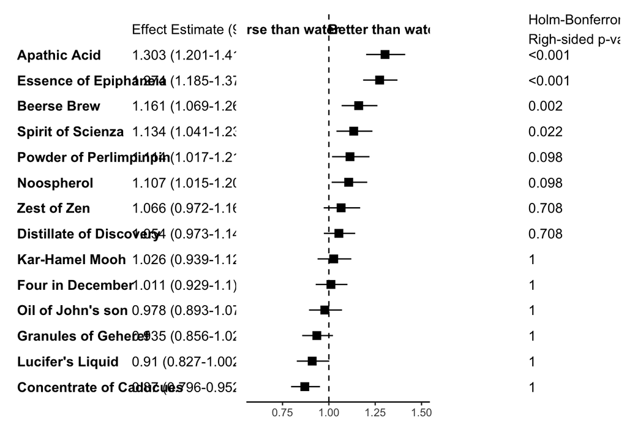

```r
output_gee2 <- output_gee2 |>
  mutate(term_compound = str_sub(term, 9),
         term_compound = term_compound %>% fct_reorder(-effect_gee))

## plotting

p_mid <-
  output_gee2 |>
  ggplot(aes(y = fct_rev(term_compound))) +
  theme_classic() +
  geom_point(aes(x=effect_gee), shape=15, size=3) +
  geom_linerange(aes(xmin=conf.low_gee, xmax=conf.high_gee)) +
  labs(x="") +
  coord_cartesian(ylim=c(1, 15), xlim=c(.6, 1.5)) +
  geom_vline(xintercept = 1, linetype="dashed") +
  annotate("text", x = .75, y = 15, label = "Worse than water", fontface="bold") +
  annotate("text", x = 1.3, y = 15, label = "Better than water", fontface="bold") +
  theme(axis.line.y = element_blank(),
        axis.ticks.y= element_blank(),
        axis.text.y= element_blank(),
        axis.title.y= element_blank())

# wrangle results into pre-plotting table form
res_plot <- output_gee2 |>
  mutate(
    # across(c(effect_gee, conf.low_gee, conf.high_gee), ~str_pad(round(.x, 2), width=4, pad="0", side="right")),
    across(c(effect_gee, conf.low_gee, conf.high_gee), ~round(.x, 3)),
    estimate_lab = paste0(effect_gee, " (", conf.low_gee, "-", conf.high_gee,")"),
    color = rep(c("gray","white"),7)
  ) |>
  mutate(adjust_right_p_value_gee = case_when(
    adjust_right_p_value_gee < .001 ~ "<0.001",
    TRUE ~ str_pad(as.character(round(adjust_right_p_value_gee, 3)), width = 1, pad = "0", side = "right")),
    conf.low_gee = conf.low_gee %>% as.character(),
    conf.high_gee = conf.high_gee %>% as.character()) |>
  bind_rows(data.frame(term = "Compound", estimate_lab = "Effect Estimate (95% CI)", conf.low_gee = "", conf.high_gee="",
                       adjust_right_p_value_gee="Holm-Bonferroni adjusted \nRigh-sided p-value")) |>
  mutate(term_compound = fct_rev(fct_relevel(term_compound, "Compound")))
# left side of plot - hazard ratios
p_left <-
  res_plot  |>
  ggplot(aes(y = term_compound)) +
  geom_text(aes(x=0, label=term_compound), hjust=0, fontface = "bold") +
  geom_text(aes(x=2.2, label=estimate_lab), hjust=0, fontface = ifelse(res_plot$estimate_lab == "95% CI", "bold", "plain")) +
  theme_void() +
  coord_cartesian(xlim=c(0,4))

# right side of plot - pvalues
p_right <-
  res_plot  |>
  ggplot() +
  geom_text(aes(x=0, y=term_compound, label=adjust_right_p_value_gee),
            hjust=0, fontface = ifelse(res_plot$adjust_right_p_value_gee == "p-value", "bold", "plain")) +
  theme_void()

# layout design (top, left, bottom, right)
#layout <- c(
  #area(t = 0, l = 0, b = 30, r = 3),
  #area(t = 1, l = 4, b = 30, r = 9),
  #area(t = 0, l = 9, b = 30, r = 11)
#)

# Final plot arrangement
# p_left + p_mid + p_right + plot_layout(design = layout)
forest_plot_poisson_gee  <- p_left + p_mid + p_right + plot_layout(widths = c(2, 1.6, 1.6))
forest_plot_poisson_gee
```

```r
ggsave("forest_plot_poisson_gee.png",
       forest_plot_poisson_gee,
       device = ragg::agg_png, res = 400, units = "in", h = 6, w = 11.5)
```

## 2.2.Logistic mixed effect model for Longitudinal binary outcome

### GEE model

In this model I specify flower as cluster, and rater as fixed effect (because GEE only allows one type of cluster).

Because we are working with binary data we need to include one further argument: scale.fix=T. This option causes the scale parameter to be fixed at its default value of 1 rather than estimated. Omitting this argument and allowing gee to estimate the scale parameter generates a quasibinomial model, which is an adjustment for overdispersion. Because binary data cannot be overdispersed, a quasibinomial model is never appropriate for binary data.

```r
m_logistic_gee <- geeglm(freshness ~ day + day:compound + garden + species + rater ,id=flowerID, family = binomial, data = binary_data2, corstr = "exchangeable", scale.fix=T)
sum_logistic_gee <- summary(m_logistic_gee)
sum_logistic_gee
```

```
##
## Call:
## geeglm(formula = freshness ~ day + day:compound + garden + species +
##     rater, family = binomial, data = binary_data2, id = flowerID,
##     corstr = "exchangeable", scale.fix = T)
##
##  Coefficients:
##                                     Estimate  Std.err   Wald
## (Intercept)                          4.15666  0.36955 126.51
## day                                 -0.42965  0.01749 603.49
## garden2                              0.19681  0.12014   2.68
## species2                            -0.36240  0.12677   8.17
## rater2                               2.65970  0.37258  50.96
## rater3                               1.19526  0.37444  10.19
## rater4                               0.93059  0.37664   6.10
## rater5                               1.56069  0.37270  17.54
## rater6                               0.95396  0.42040   5.15
## rater7                               1.61555  0.37556  18.50
## rater8                               0.02116  0.37751   0.00
## rater9                               1.43944  0.37322  14.88
## rater10                              1.37028  0.37540  13.32
## day:compoundApathic Acid             0.10256  0.01899  29.18
## day:compoundBeerse Brew              0.06627  0.01965  11.37
## day:compoundConcentrate of Caducues -0.04499  0.02287   3.87
## day:compoundDistillate of Discovery  0.02074  0.02084   0.99
## day:compoundEssence of Epiphaneia    0.09867  0.01872  27.78
## day:compoundFour in December         0.00934  0.02072   0.20
## day:compoundGranules of Geheref     -0.02987  0.02400   1.55
## day:compoundKar-Hamel Mooh           0.01880  0.02047   0.84
## day:compoundLucifer's Liquid        -0.04101  0.02310   3.15
## day:compoundNoospherol               0.04931  0.02032   5.89
## day:compoundOil of John's son       -0.00204  0.02196   0.01
## day:compoundPowder of Perlimpinpin   0.05176  0.01977   6.85
## day:compoundSpirit of Scienza        0.04735  0.01948   5.91
## day:compoundZest of Zen              0.03732  0.01961   3.62
##                                                 Pr(>|W|)
## (Intercept)                         < 0.0000000000000002 ***
## day                                 < 0.0000000000000002 ***
## garden2                                          0.10138
## species2                                         0.00425 **
```

[output cut: 20 more lines]

```
## day:compoundPowder of Perlimpinpin               0.00885 **
## day:compoundSpirit of Scienza                    0.01506 *
## day:compoundZest of Zen                          0.05709 .
## ---
## Signif. codes:  0 '***' 0.001 '**' 0.01 '*' 0.05 '.' 0.1 ' ' 1
##
## Correlation structure = exchangeable
## Scale is fixed.
##
##   Link = identity
##
## Estimated Correlation Parameters:
##       Estimate Std.err
## alpha    0.337  0.0789
## Number of clusters:   1451  Maximum cluster size: 25
```

Choose correlation structures:

```r
m_logistic_gee2 <- geeglm(freshness ~ day + day:compound + garden + species + rater ,id=flowerID, family = binomial, data = binary_data2, corstr = "unstructured", scale.fix=T)
QIC(m_logistic_gee, m_logistic_gee2)
```

[output not shown]

Model output:

```r
options(scipen=999)
effect_gee_l = round(exp(sum_logistic_gee$coefficients[,1]), digits = 3)
conf.low_gee_l <- round(exp(sum_logistic_gee$coefficients[,1] + qnorm(0.025)*sum_logistic_gee$coefficients[,2]) , digits = 3)
conf.high_gee_l <- round(exp(sum_logistic_gee$coefficients[,1] + qnorm(0.975)*sum_logistic_gee$coefficients[,2]) , digits = 3)
p_value_gee <- round(sum_logistic_gee$coefficients[,4], digits = 5) #right-sided p-value
output_gee_l<- data.frame( cbind(effect_gee_l, conf.low_gee_l, conf.high_gee_l, p_value_gee))
output_gee_l<- output_gee_l %>% mutate(term = rownames(sum_logistic_gee$coefficients)) %>% relocate(term)
output_gee_l$term <- as.factor(output_gee_l$term)
output_gee_l2 <- output_gee_l %>% slice(-c(1:13))
output_gee_l2
```

```
##                                   term effect_gee_l conf.low_gee_l
## 1             day:compoundApathic Acid        1.108          1.068
## 2              day:compoundBeerse Brew        1.069          1.028
## 3  day:compoundConcentrate of Caducues        0.956          0.914
## 4  day:compoundDistillate of Discovery        1.021          0.980
## 5    day:compoundEssence of Epiphaneia        1.104          1.064
## 6         day:compoundFour in December        1.009          0.969
## 7      day:compoundGranules of Geheref        0.971          0.926
## 8           day:compoundKar-Hamel Mooh        1.019          0.979
## 9         day:compoundLucifer's Liquid        0.960          0.917
## 10              day:compoundNoospherol        1.051          1.010
## 11       day:compoundOil of John's son        0.998          0.956
## 12  day:compoundPowder of Perlimpinpin        1.053          1.013
## 13       day:compoundSpirit of Scienza        1.048          1.009
## 14             day:compoundZest of Zen        1.038          0.999
##    conf.high_gee_l p_value_gee
## 1             1.15     0.00000
## 2             1.11     0.00075
## 3             1.00     0.04922
## 4             1.06     0.31968
## 5             1.15     0.00000
## 6             1.05     0.65201
## 7             1.02     0.21315
## 8             1.06     0.35856
## 9             1.00     0.07578
## 10            1.09     0.01525
## 11            1.04     0.92589
## 12            1.09     0.00885
## 13            1.09     0.01506
## 14            1.08     0.05709
```

Visualize output: Forest plot:

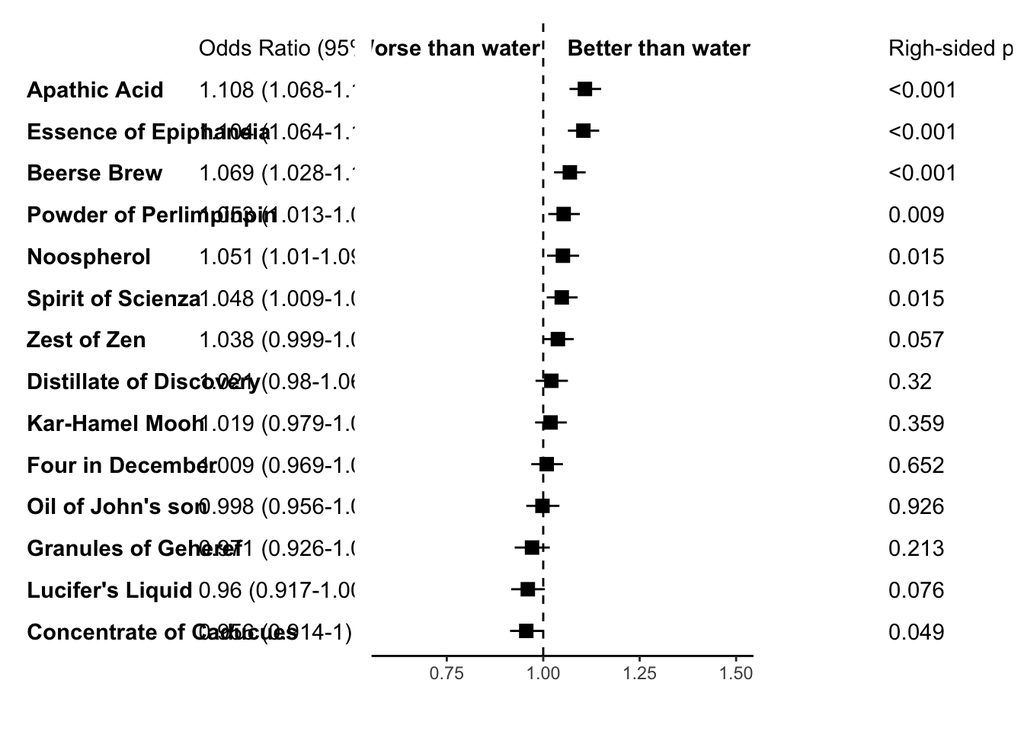

```r
output_gee_l2 <- output_gee_l2 |>
  mutate(term_compound = str_sub(term, 13),
         term_compound = term_compound %>% fct_reorder(-effect_gee_l))

## plotting

p_mid <-
  output_gee_l2 |>
  ggplot(aes(y = fct_rev(term_compound))) +
  theme_classic() +
  geom_point(aes(x=effect_gee_l), shape=15, size=3) +
  geom_linerange(aes(xmin=conf.low_gee_l, xmax=conf.high_gee_l)) +
  labs(x="") +
  coord_cartesian(ylim=c(1, 15), xlim=c(.6, 1.5)) +
  geom_vline(xintercept = 1, linetype="dashed") +
  annotate("text", x = .75, y = 15, label = "Worse than water", fontface="bold") +
  annotate("text", x = 1.3, y = 15, label = "Better than water", fontface="bold") +
  theme(axis.line.y = element_blank(),
        axis.ticks.y= element_blank(),
        axis.text.y= element_blank(),
        axis.title.y= element_blank())

# wrangle results into pre-plotting table form
res_plot <- output_gee_l2 |>
  mutate(
    # across(c(effect_gee_l, conf.low_gee_l, conf.high_gee_l), ~str_pad(round(.x, 2), width=4, pad="0", side="right")),
    across(c(effect_gee_l, conf.low_gee_l, conf.high_gee_l), ~round(.x, 3)),
    estimate_lab = paste0(effect_gee_l, " (", conf.low_gee_l, "-", conf.high_gee_l,")"),
    color = rep(c("gray","white"),7)
  ) |>
  mutate(p_value_gee = case_when(
    p_value_gee < .001 ~ "<0.001",
    TRUE ~ str_pad(as.character(round(p_value_gee, 3)), width = 1, pad = "0", side = "right")),
    conf.low_gee_l = conf.low_gee_l %>% as.character(),
    conf.high_gee_l = conf.high_gee_l %>% as.character()) |>
  bind_rows(data.frame(term = "Compound", estimate_lab = "Odds Ratio (95% CI)", conf.low_gee_l = "", conf.high_gee_l="",
                       p_value_gee_l="p-value",
                       p_value_gee="Righ-sided p-value")) |>
  mutate(term_compound = fct_rev(fct_relevel(term_compound, "Compound")))
# left side of plot - Odds ratios
p_left <-
  res_plot  |>
  ggplot(aes(y = term_compound)) +
  geom_text(aes(x=0, label=term_compound), hjust=0, fontface = "bold") +
  geom_text(aes(x=2.2, label=estimate_lab), hjust=0, fontface = ifelse(res_plot$estimate_lab == "95% CI", "bold", "plain")) +
  theme_void() +
  coord_cartesian(xlim=c(0,4))

# right side of plot - pvalues
p_right <-
  res_plot  |>
  ggplot() +
  geom_text(aes(x=0, y=term_compound, label=p_value_gee), hjust=0, fontface = ifelse(res_plot$p_value_gee == "p-value", "bold", "plain")) +
  theme_void()


# Final plot arrangement
# p_left + p_mid + p_right + plot_layout(design = layout)
forest_plot_logistic_gee <- p_left + p_mid + p_right + plot_layout(widths = c(1.8, 2, 1.3))
forest_plot_logistic_gee
```

```r
ggsave("forest_plot_logistic_gee.png",
       forest_plot_logistic_gee,
       device = ragg::agg_png, res = 400, units = "in", h = 6, w = 11.5)
```

## 2.3.Linear mixed effect model for gaussian data

We fit a mixed-effect linear model of the flower width as a function of time, specie, garden, flower and subplot. Flower and subplot are considered random effect. The effect of interest is the interaction term day:compound, corresponding to the effect of each compound on width of flower per 1-day increase in time.

Significance is determined by left-sided p-value. We do not adjust for multiple comparision because this is secondary analysis.

```r
linear_model <- lmer(width ~ day + day:Compound + Garden + Type + (1|Subplot) + (1|Subplot:Flower_index), data = conti_data_long)
sum_linear_model <- summary(linear_model)
sum_linear_model
```

```
## Linear mixed model fit by REML. t-tests use Satterthwaite's method [
## lmerModLmerTest]
## Formula: width ~ day + day:Compound + Garden + Type + (1 | Subplot) +
##     (1 | Subplot:Flower_index)
##    Data: conti_data_long
##
## REML criterion at convergence: 4078
##
## Scaled residuals:
##    Min     1Q Median     3Q    Max
## -4.666 -0.536 -0.004  0.560  6.520
##
## Random effects:
##  Groups               Name        Variance Std.Dev.
##  Subplot:Flower_index (Intercept) 0.2693   0.519
##  Subplot              (Intercept) 0.0212   0.146
##  Residual                         0.1435   0.379
## Number of obs: 3660, groups:  Subplot:Flower_index, 180; Subplot, 18
##
## Fixed effects:
##                                       Estimate Std. Error         df t value
## (Intercept)                            3.15883    0.08414   26.90044   37.54
## day                                    0.23580    0.00382 3618.53046   61.66
## Garden2                                0.36587    0.10422   15.97376    3.51
## Type2                                  2.05639    0.07844  147.12472   26.21
## day:CompoundApathic Acid              -0.09817    0.00540 3612.05697  -18.19
## day:CompoundBeerse Brew               -0.07807    0.00552 3614.06318  -14.15
## day:CompoundConcentrate of Caducues    0.15473    0.00551 3592.12313   28.10
## day:CompoundDistillate of Discovery   -0.01690    0.00540 3612.05697   -3.13
## day:CompoundEssence of Epiphaneia     -0.07591    0.00549 3612.03807  -13.82
## day:CompoundFour in December          -0.01440    0.00539 3591.79847   -2.67
## day:CompoundGranules of Geheref        0.07905    0.00561 3612.43831   14.09
## day:CompoundKar-Hamel Mooh            -0.01364    0.00576 3608.95550   -2.37
## day:CompoundLucifer's Liquid           0.10734    0.00539 3591.79847   19.90
## day:CompoundNoospherol                -0.03982    0.00540 3612.05697   -7.38
## day:CompoundOil of John's son          0.03442    0.00552 3613.71123    6.24
## day:CompoundPowder of Perlimpinpin    -0.04560    0.00539 3591.79847   -8.45
## day:CompoundSpirit of Scienza         -0.09144    0.00549 3610.73289  -16.64
## day:CompoundZest of Zen               -0.06011    0.00540 3612.02167  -11.14
##                                                 Pr(>|t|)
## (Intercept)                         < 0.0000000000000002 ***
## day                                 < 0.0000000000000002 ***
## Garden2                                           0.0029 **
## Type2                               < 0.0000000000000002 ***
## day:CompoundApathic Acid            < 0.0000000000000002 ***
## day:CompoundBeerse Brew             < 0.0000000000000002 ***
## day:CompoundConcentrate of Caducues < 0.0000000000000002 ***
## day:CompoundDistillate of Discovery               0.0018 **
## day:CompoundEssence of Epiphaneia   < 0.0000000000000002 ***
## day:CompoundFour in December                      0.0076 **
## day:CompoundGranules of Geheref     < 0.0000000000000002 ***
## day:CompoundKar-Hamel Mooh                        0.0180 *
## day:CompoundLucifer's Liquid        < 0.0000000000000002 ***
## day:CompoundNoospherol                   0.0000000000002 ***
## day:CompoundOil of John's son            0.0000000004967 ***
## day:CompoundPowder of Perlimpinpin  < 0.0000000000000002 ***
## day:CompoundSpirit of Scienza       < 0.0000000000000002 ***
## day:CompoundZest of Zen             < 0.0000000000000002 ***
## ---
## Signif. codes:  0 '***' 0.001 '**' 0.01 '*' 0.05 '.' 0.1 ' ' 1
```

```
##
## Correlation matrix not shown by default, as p = 18 > 12.
## Use print(x, correlation=TRUE)  or
##     vcov(x)        if you need it
```

Check model assumptions:

```r
library(effects)
```

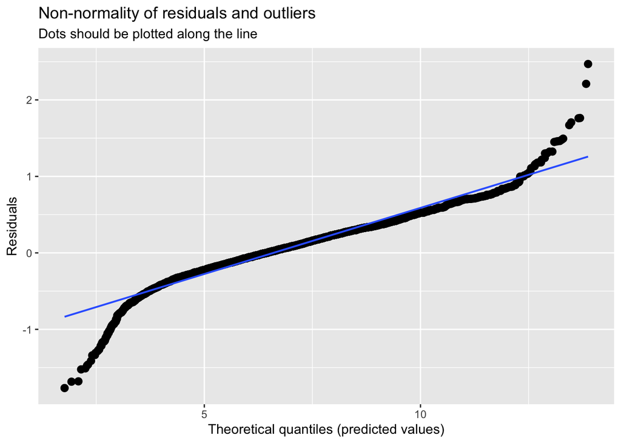

```
##
## [[2]]
## [[2]]$`Subplot:Flower_index`
```

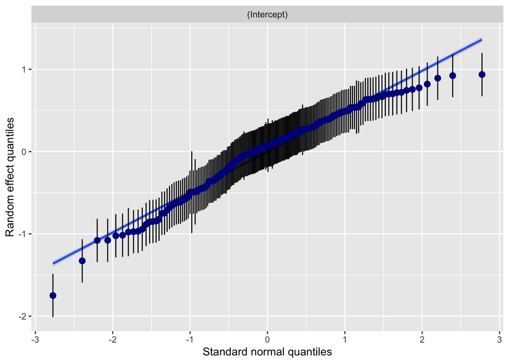

```
##
## [[2]]$Subplot
```

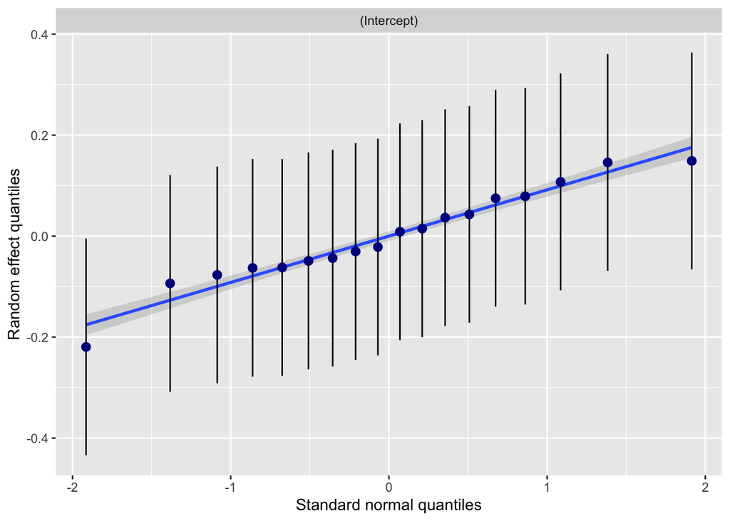

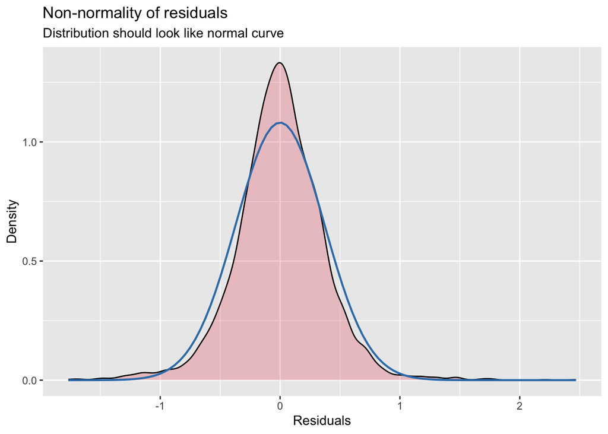

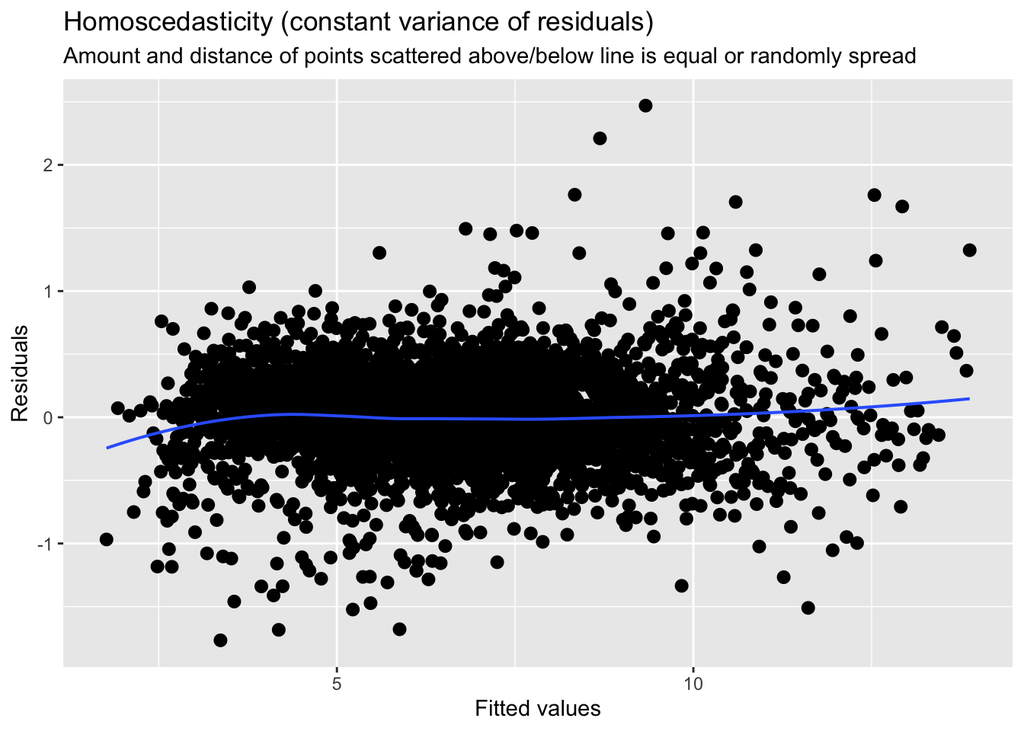

```r
library(sjPlot)
plot_model(linear_model, type='diag')
```

Assumptions of linearity, normality and constant variance seems to be met.

### Summary of effect:

```r
options(scipen=999)
effect_linear <- round(sum_linear_model$coefficients[,1], digits = 3)
conf.low_linear <- round(sum_linear_model$coefficients[,1] + qnorm(0.025)*sum_linear_model$coefficients[,2] , digits = 3)
conf.high_linear <- round(sum_linear_model$coefficients[,1] + qnorm(0.975)*sum_linear_model$coefficients[,2], digits = 3)
left_p_value_linear <- round(if_else(sum_linear_model$coefficients[,4] <0, sum_linear_model$coefficients[,5]/2, 1 -(sum_linear_model$coefficients[,5]/2)), digits = 7) #left-sided p-value
output_linear<- data.frame( cbind(effect_linear, left_p_value_linear, conf.low_linear, conf.high_linear))
output_linear<- output_linear %>% mutate(term = rownames(output_linear)) %>% relocate(term)
rownames(output_linear) <- NULL
output_linear$term <- as.factor(output_linear$term)
output_linear2 <- output_linear %>% dplyr::filter( grepl("day:Compound", term))
output_linear2
```

```
##                                   term effect_linear left_p_value_linear
## 1             day:CompoundApathic Acid        -0.098            0.000000
## 2              day:CompoundBeerse Brew        -0.078            0.000000
## 3  day:CompoundConcentrate of Caducues         0.155            1.000000
## 4  day:CompoundDistillate of Discovery        -0.017            0.000879
## 5    day:CompoundEssence of Epiphaneia        -0.076            0.000000
## 6         day:CompoundFour in December        -0.014            0.003800
## 7      day:CompoundGranules of Geheref         0.079            1.000000
## 8           day:CompoundKar-Hamel Mooh        -0.014            0.008999
## 9         day:CompoundLucifer's Liquid         0.107            1.000000
## 10              day:CompoundNoospherol        -0.040            0.000000
## 11       day:CompoundOil of John's son         0.034            1.000000
## 12  day:CompoundPowder of Perlimpinpin        -0.046            0.000000
## 13       day:CompoundSpirit of Scienza        -0.091            0.000000
## 14             day:CompoundZest of Zen        -0.060            0.000000
##    conf.low_linear conf.high_linear
## 1           -0.109           -0.088
## 2           -0.089           -0.067
## 3            0.144            0.166
## 4           -0.027           -0.006
## 5           -0.087           -0.065
## 6           -0.025           -0.004
## 7            0.068            0.090
## 8           -0.025           -0.002
## 9            0.097            0.118
## 10          -0.050           -0.029
## 11           0.024            0.045
## 12          -0.056           -0.035
## 13          -0.102           -0.081
## 14          -0.071           -0.050
```

### Visualize effect:

Forest plot

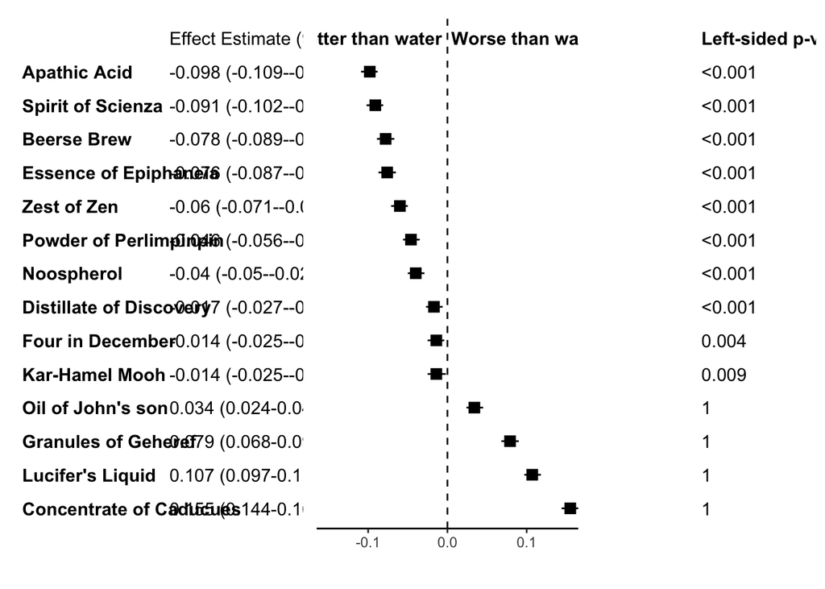

```r
output_linear2 <- output_linear2 |>
  mutate(term_compound = str_sub(term, 13),
         term_compound = term_compound %>% fct_reorder(effect_linear))

## plotting

p_mid <-
  output_linear2 |>
  ggplot(aes(y = fct_rev(term_compound))) +
  theme_classic() +
  geom_point(aes(x=effect_linear), shape=15, size=3) +
  geom_linerange(aes(xmin=conf.low_linear, xmax=conf.high_linear)) +
  labs(x="") +
  coord_cartesian(ylim=c(1, 15), xlim=c(-0.15, 0.15)) +
  geom_vline(xintercept = 0, linetype="dashed") +
  annotate("text", x = -0.1, y = 15, label = "Better than water", fontface="bold") +
  annotate("text", x = 0.1, y = 15, label = "Worse than water", fontface="bold") +
  theme(axis.line.y = element_blank(),
        axis.ticks.y= element_blank(),
        axis.text.y= element_blank(),
        axis.title.y= element_blank())

# wrangle results into pre-plotting table form
res_plot <- output_linear2 |>
  mutate(
    # across(c(effect_linear, conf.low_linear, conf.high_linear), ~str_pad(round(.x, 2), width=4, pad="0", side="right")),
    across(c(effect_linear, conf.low_linear, conf.high_linear), ~round(.x, 3)),
    estimate_lab = paste0(effect_linear, " (", conf.low_linear, "-", conf.high_linear,")"),
    color = rep(c("gray","white"),7)
  ) |>
  mutate(left_p_value_linear = case_when(
    left_p_value_linear < .001 ~ "<0.001",
    TRUE ~ str_pad(as.character(round(left_p_value_linear, 3)), width = 1, pad = "0", side = "right")),
    conf.low_linear = conf.low_linear %>% as.character(),
    conf.high_linear = conf.high_linear %>% as.character()) |>
  bind_rows(data.frame(term = "Compound", estimate_lab = "Effect Estimate (95% CI)",
                       conf.low_linear = "", conf.high_linear="",
                       left_p_value_linear="Left-sided p-value")) |>
  mutate(term_compound = fct_rev(fct_relevel(term_compound, "Compound")))
# left side of plot - hazard ratios
p_left <-
  res_plot  |>
  ggplot(aes(y = term_compound)) +
  geom_text(aes(x=0, label=term_compound), hjust=0, fontface = "bold") +
  geom_text(aes(x=2.2, label=estimate_lab), hjust=0, fontface = ifelse(res_plot$estimate_lab == "95% CI", "bold", "plain")) +
  theme_void() +
  coord_cartesian(xlim=c(0,4))

# right side of plot - pvalues
p_right <-
  res_plot  |>
  ggplot() +
  geom_text(aes(x=0, y=term_compound, label=left_p_value_linear), hjust=0, fontface = ifelse(res_plot$left_p_value_linear == "Left-sided p-value", "bold", "plain")) +
  theme_void()


# Final plot arrangement
# p_left + p_mid + p_right + plot_layout(design = layout)
forest_plot_linear <- p_left + p_mid + p_right + plot_layout(widths = c(1.8, 1.6, 1.4))
forest_plot_linear
```

```r
ggsave("forest_plot_linear.png",
       forest_plot_linear,
       device = ragg::agg_png, res = 400, units = "in", h = 6, w = 11.5)
```